[figure not shown]

# Un problema de segmentación de imágenes

En este notebook verás una posible solución a un problema de segmentación de imágenes utilizando los algoritmos KMeans y Mean Shift. En particular, se cargará un conjunto de datos de imágenes con tres canales de colores, y se mostrará la construcción de dos modelos de segmentación utilizando cada algoritmo, resultando en la generación de una paleta de colores para una imagen. En este sentido, veremos cómo realizar los siguientes procesos:

1. Importar las librerías necesarias.
2. Cargar un conjunto de datos de imágenes.
3. Realizar una segmentación usando los algoritmos KMeans y Mean Shift.

## 1. Importación de librerías requeridas

Importaremos las librerías `numpy`, `os` y `cv2` para la carga y procesamiento de las imágenes, así como la librería `scikit_learn` para usar los algoritmos de agrupación y la librería `matplotlib` para visualizar las imágenes resultantes:

```python
import numpy as np
import os
import cv2
import matplotlib.pyplot as plt

from sklearn.cluster import KMeans, MeanShift, estimate_bandwidth
```

## 2. Carga de datos

Definiremos una funcion `load_images()` para la carga de las imágenes. Esta función asume que se tiene un directorio o carpeta con las imágenes, y utiliza funciones como `imread()` y `cvtColor()` para realizar la carga y procesamiento de cada una:

```python
def load_images(root_path, file_names, flatten=True, normalize=True):
    """
    Retorna una lista con arreglos de números. Cada arreglo representa una imagen RGB.

    Parametros:
    root_path : str
        Directorio raíz de las imágenes.
    file_names : list
        Lista con los nombres de los archivos de imágenes.
    flatten : bool, opcional
        Si es True, aplana las imágenes a una lista de píxeles de tres dimensiones.
    normalize : bool, opcional
        Si es True, normaliza los valores de píxeles al rango [0, 1].
    """
    image_list = list()
    for file in file_names:
        img = cv2.imread(os.path.join(root_path, file))
        img = cv2.cvtColor(img, cv2.COLOR_BGR2RGB)
        if flatten:
            img = img.reshape((-1, 3))
        if normalize:
            img = img / 255.0
        image_list.append(img)
    return image_list
```

En ese sentido, definiremos el directorio raíz `root_path` y la lista de imágenes `img_files`:

```python
root_path = 'data'
```

```python
img_files = os.listdir(root_path)
img_files
```

```
['imagen2.jpg', 'imagen3.jpg']
```

Primero realizaremos la carga de las imágenes sin modificaciones, es decir, manteniendo tanto las dimensiones originales como los valores de píxeles:

```python
img_original = load_images(root_path, img_files, flatten=False, normalize=False)
img_original
```

```
[array([[[254, 253, 255],
         [254, 253, 255],
         [254, 253, 255],
         ...,
         [246, 245, 250],
         [246, 245, 250],
         [246, 245, 250]],

        [[254, 253, 255],
         [254, 253, 255],
         [254, 253, 255],
         ...,
         [246, 245, 250],
         [246, 245, 250],
         [246, 245, 250]],

        [[254, 253, 255],
         [254, 253, 255],
         [254, 253, 255],
         ...,
         [246, 245, 250],
         [246, 245, 250],
         [246, 245, 250]],

        ...,

        [[248, 249, 253],
         [248, 249, 253],
         [248, 249, 253],
         ...,
         [230, 234, 233],
         [230, 234, 233],
         [230, 234, 233]],

        [[249, 250, 254],
         [249, 250, 254],
         [249, 250, 254],
         ...,
         [236, 240, 239],
         [236, 240, 239],
```

[output cut: 43 more lines]

```
        [[184, 175,  70],
         [117, 109,  10],
         [ 95,  85,   0],
         ...,
         [ 24,  16,   5],
         [ 40,  37,  20],
         [ 42,  43,  25]],

        [[128, 121,  14],
         [127, 119,  18],
         [123, 113,  24],
         ...,
         [ 43,  36,  20],
         [ 28,  26,   5],
         [ 53,  53,  29]]], dtype=uint8)]
```

Por otro lado, realizaremos la carga de las imágenes como una lista de píxeles, normalizando sus valores para que estén en el rango [0, 1]. Este será el conjunto de datos que utilizaremos para el entrenamiento de los modelos:

```python
img_list = load_images(root_path, img_files, flatten=True, normalize=True)
img_list
```

```
[array([[0.99607843, 0.99215686, 1.        ],
        [0.99607843, 0.99215686, 1.        ],
        [0.99607843, 0.99215686, 1.        ],
        ...,
        [0.94509804, 0.96862745, 0.96078431],
        [0.94509804, 0.96862745, 0.96078431],
        [0.94509804, 0.96862745, 0.96078431]]),
 array([[0.04705882, 0.62745098, 0.91764706],
        [0.02745098, 0.58431373, 0.88235294],
        [0.05882353, 0.57254902, 0.88627451],
        ...,
        [0.16862745, 0.14117647, 0.07843137],
        [0.10980392, 0.10196078, 0.01960784],
        [0.20784314, 0.20784314, 0.11372549]])]
```

```python
img_original[0].shape
```

```
(267, 188, 3)
```

```python
img_list[0].shape
```

```
(50196, 3)
```

## 3. Segmentación de imágenes

En este notebook mostraremos dos posibles métodos para realizar la segmentación, empezando por el algoritmo KMeans:

## KMeans

En esta versión, primero debemos especificar el número de clústeres. Por ejemplo, realizaremos una segmentación con cinco clústeres:

```python
num_clusters = 5
```

Y aplicaremos el algoritmo sobre la imagen `img_list[1]`:

```python
kmeans = KMeans(n_clusters=num_clusters)
kmeans.fit(img_list[1])
```

```
KMeans(n_clusters=5)
```

Podemos ver la paleta de colores resultante como los centroides encontrados por el modelo:

```python
labels = kmeans.labels_
centroids = kmeans.cluster_centers_
centroids
```

```
array([[0.26575798, 0.62877085, 0.829446  ],
       [0.25488995, 0.22633822, 0.08702907],
       [0.65058433, 0.6113368 , 0.38698626],
       [0.61284526, 0.7801604 , 0.92735214],
       [0.45664231, 0.42051737, 0.18239836]])
```

Y podemos generar una máscara o imagen segmentada con la expresión `centroids[labels]`. Ten en cuenta que, para visualizar la imagen correctamente, reescalamos los valores de píxeles al rango original de [0, 255], y volvemos a las dimensiones originales con `reshape()`:

```python
img_segmented = centroids[labels]*255
img_segmented = img_segmented.reshape(img_original[1].shape)
```

A continuación puedes visualizar el resultado:

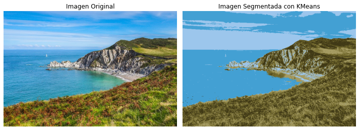

```python
plt.figure(figsize=(10, 5))

plt.subplot(1, 2, 1)
plt.title('Imagen Original')
plt.imshow(img_original[1])
plt.axis('off')

plt.subplot(1, 2, 2)
plt.title('Imagen Segmentada con KMeans')
plt.imshow(img_segmented.astype(np.uint8))
plt.axis('off')

plt.tight_layout()
plt.show()
```

## Mean Shift

El siguiente método, con el algoritmo Mean Shift, no necesita especificar el número de clústeres, pero sí necesita estimar una ventana:

```python
bandwidth = estimate_bandwidth(img_list[0], quantile=0.2, n_samples=100)
```

Con la ventana definida, aplicaremos el algoritmo sobre la imagen almacenada en `img_list[0]`:

```python
meanshift = MeanShift(bandwidth=bandwidth, bin_seeding=True)
meanshift.fit(img_list[0])
```

```
MeanShift(bandwidth=0.15763936459318403, bin_seeding=True)
```

Al igual que con KMeans, podemos ver la paleta de colores resultante como la lista de centroides:

```python
labels = meanshift.labels_
centroids = meanshift.cluster_centers_
centroids
```

```
array([[0.97222386, 0.97203656, 0.97226042],
       [0.64606891, 0.42208859, 0.27549893],
       [0.24147813, 0.27358162, 0.11808504]])
```

También generaremos la máscara o imagen segmentada para visualizar el resultado:

```python
img_segmented = centroids[labels]*255
img_segmented = img_segmented.reshape(img_original[0].shape)
```

La imagen original y el resultado se pueden observar a continuación:

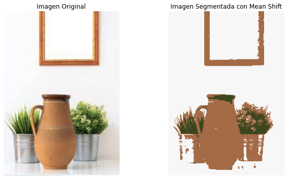

```python
plt.figure(figsize=(10, 5))

plt.subplot(1, 2, 1)
plt.title('Imagen Original')
plt.imshow(img_original[0])
plt.axis('off')

plt.subplot(1, 2, 2)
plt.title('Imagen Segmentada con Mean Shift')
plt.imshow(img_segmented.astype(np.uint8))
plt.axis('off')

plt.tight_layout()
plt.show()
```

## Cierre

En este notebook viste una posible solución a un problema de segmentación utilizando los algoritmos KMeans y Mean Shift. En particular, observaste dos métodos que se diferencian en la definición del número de clústeres, generando una paleta de colores para una imagen particular. Ten en cuenta que el procesamiento y algoritmos utilizados no son los únicos que pueden dar solución a este problema, por lo que puedes utilizar otro tipo de procesamiento y algoritmos de agrupación diferentes para obtener diversos resultados.

*Creado por: Nicolás Díaz*  
*Revisado por: Haydemar Nuñez*  
*Versión de: Diciembre 13, 2023*  
*Universidad de los Andes*